# Animal Conservation

# Brief

You work for an animal conservation organisation and are looking to do some investigating into some of the animals to provide evidence for some projects you are looking to run. (use the msleep data set provided in the ggplot package)

```r
library(tidyverse)

data(msleep)
```

Briefly exploring the data:

```r
library(janitor)

glimpse(msleep)
```

```
Rows: 83
Columns: 11
$ name         <chr> "Cheetah", "Owl monkey", "Mountain beaver", "Greater short-tailed shrew", "Cow", "Three-toed sloth", "Northern fur seal", "Vesper mouse"…
$ genus        <chr> "Acinonyx", "Aotus", "Aplodontia", "Blarina", "Bos", "Bradypus", "Callorhinus", "Calomys", "Canis", "Capreolus", "Capri", "Cavis", "Cerc…
$ vore         <chr> "carni", "omni", "herbi", "omni", "herbi", "herbi", "carni", NA, "carni", "herbi", "herbi", "herbi", "omni", "herbi", "omni", "omni", "o…
$ order        <chr> "Carnivora", "Primates", "Rodentia", "Soricomorpha", "Artiodactyla", "Pilosa", "Carnivora", "Rodentia", "Carnivora", "Artiodactyla", "Ar…
$ conservation <chr> "lc", NA, "nt", "lc", "domesticated", NA, "vu", NA, "domesticated", "lc", "lc", "domesticated", "lc", "domesticated", "lc", NA, "lc", "l…
$ sleep_total  <dbl> 12.1, 17.0, 14.4, 14.9, 4.0, 14.4, 8.7, 7.0, 10.1, 3.0, 5.3, 9.4, 10.0, 12.5, 10.3, 8.3, 9.1, 17.4, 5.3, 18.0, 3.9, 19.7, 2.9, 3.1, 10.1…
$ sleep_rem    <dbl> NA, 1.8, 2.4, 2.3, 0.7, 2.2, 1.4, NA, 2.9, NA, 0.6, 0.8, 0.7, 1.5, 2.2, 2.0, 1.4, 3.1, 0.5, 4.9, NA, 3.9, 0.6, 0.4, 3.5, 1.1, NA, 3.2, 1…
$ sleep_cycle  <dbl> NA, NA, NA, 0.1333333, 0.6666667, 0.7666667, 0.3833333, NA, 0.3333333, NA, NA, 0.2166667, NA, 0.1166667, NA, NA, 0.1500000, 0.3833333, N…
$ awake        <dbl> 11.90, 7.00, 9.60, 9.10, 20.00, 9.60, 15.30, 17.00, 13.90, 21.00, 18.70, 14.60, 14.00, 11.50, 13.70, 15.70, 14.90, 6.60, 18.70, 6.00, 20…
$ brainwt      <dbl> NA, 0.01550, NA, 0.00029, 0.42300, NA, NA, NA, 0.07000, 0.09820, 0.11500, 0.00550, NA, 0.00640, 0.00100, 0.00660, 0.00014, 0.01080, 0.01…
$ bodywt       <dbl> 50.000, 0.480, 1.350, 0.019, 600.000, 3.850, 20.490, 0.045, 14.000, 14.800, 33.500, 0.728, 4.750, 0.420, 0.060, 1.000, 0.005, 3.500, 2.9…
```

##Jabberwockies sleep for around 7 hours a night, on average. Perform an appropriate statistical test to determine whether the mean sleep_total in the sampled population of animal types differs from the typical value for jabberwockies.

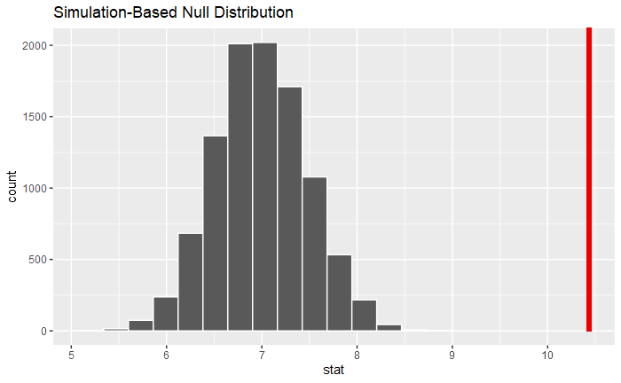

```r
library(infer)

null_distribution <- msleep %>%
  specify(response = sleep_total) %>%
  hypothesize(null = "point", mu = 7) %>%
  generate(reps = 10000, type = "bootstrap") %>%
  calculate(stat = "mean")

obs_stat <- msleep %>%
  specify(response = sleep_total) %>%
  calculate(stat = "mean")

null_distribution %>%
  visualise() +
  shade_p_value(direction = "both", obs_stat = obs_stat)
```

```r
null_distribution %>%
  get_p_value(direction = "both", obs_stat = obs_stat)
```

| p_value |
| --- |
| 0 |

The p-value is below α and so we reject H0 and conclude that the mean sleep_total in the sampled population of animal types differs significantly from the value of 7 hours typical of jabberwockies.

##Perform an appropriate statistical test to determine whether omnivores sleep for significantly longer than herbivores, on average.

```r
msleep %>%
  distinct(vore)
```

| vore |
| --- |
| carni |
| omni |
| herbi |
| NA |
| insecti |

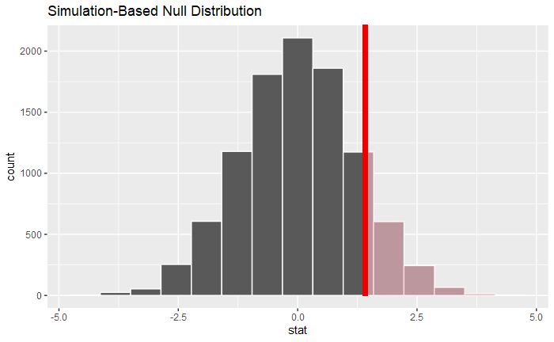

```r
null_distribution <- msleep %>%
  filter(vore %in% c("omni", "herbi")) %>%
  specify(sleep_total ~ vore) %>%
  hypothesize(null = "independence") %>%
  generate(reps = 10000, type = "permute") %>%
  calculate(stat = "diff in means", order = c("omni", "herbi"))

obs_stat <- msleep %>%
  filter(vore %in% c("omni", "herbi")) %>%
  specify(sleep_total ~ vore) %>%
  calculate(stat = "diff in means", order = c("omni", "herbi"))

null_distribution %>%
  visualise() +
  shade_p_value(direction = "right", obs_stat = obs_stat)
```

```r
null_distribution %>%
  get_p_value(direction = "right", obs_stat = obs_stat)
```

| p_value |
| --- |
| 0.1198 |

The p-value is equal to or greater than α, and so we fail to reject H0. There is insufficient evidence to conclude that omnivores sleep for significantly longer than herbivores on average.

##Perform an appropriate statistical test to determine whether the proportion of domesticated animal types in the population of ani mal types is greater than 5%.

```r
msleep_domesticated_flag <- msleep %>%
  mutate(domesticated_flag = if_else(conservation == "domesticated", 1, 0))

null_distribution <- msleep_domesticated_flag %>%
  specify(response = domesticated_flag) %>%
  hypothesize(null = "point", mu = 0.05) %>%
  generate(reps = 10000, type = "bootstrap") %>%
  calculate(stat = "mean")
```

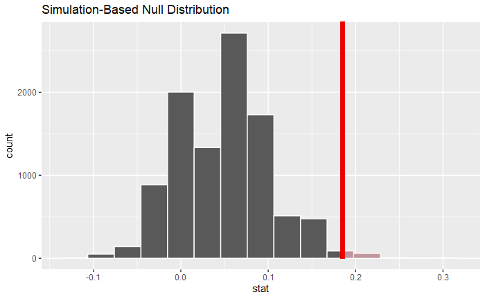

```r
null_distribution %>%
  visualise() +
  shade_p_value(direction = "right", obs_stat = obs_stat)
```

```r
null_distribution %>%
  get_p_value(direction = "right", obs_stat = obs_stat)
```

| p_value |
| --- |
| 0.0064 |

The p-value is less than α, so we reject H0 and accept that the proportion of domesticated animal types in the data is significantly greater than 5%.